# Corporate Finance

Lecture 1: Capital Markets and the Pricing of Risk

Camilo Saldarriaga

Finance Department, ESCP Business School, 2026/2027

## Plan

- Learn some general concepts
- Learn how to compute returns
- Understand how we measure risk
- Understand what is an index

## Key concepts

- Compute/estimate returns and risk
- Risk-return relationship of assets

## Outline

1. Risk and return: a first glimpse (Chap. 10.1)
2. Common return measures (Chap. 10.2)
3. Historical returns of stocks and bonds (Chap. 10.3)
4. Common measures of risk (Chap. 10.2)
5. The historical risk-return trade-off (Chap. 10.4)
6. Risk and returns of individual stocks (Chap. 10.4)

**But first, let’s battle a monster.**

$\sum$

*This is a monster you will find along the course several times*

**Initially it may look scary…**

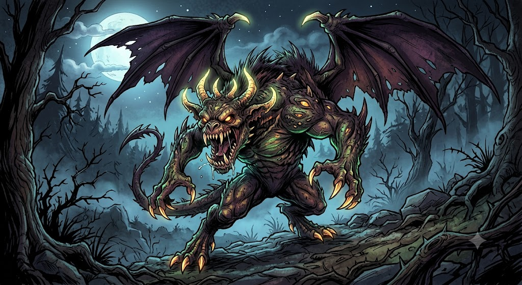

**But hopefully, you will see that the monster is not that scary**

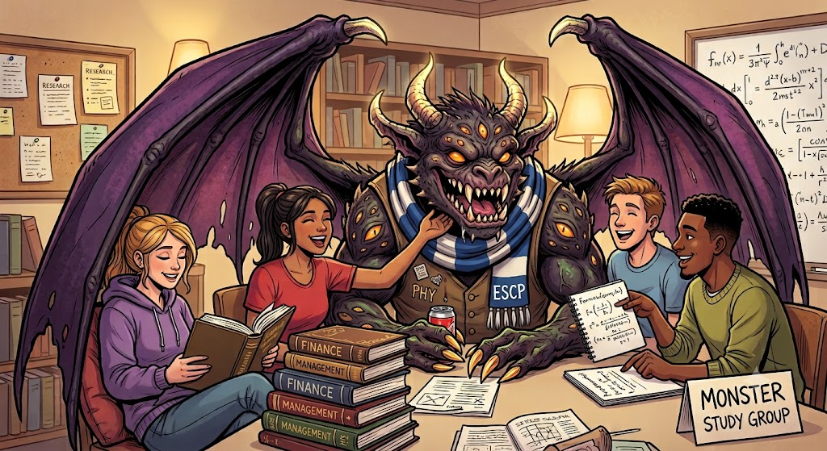

## The monster only means “add these up”

- The symbol $\sum$ is the Greek letter S, and S stands for **sum**. It is a shortcut for writing a long addition.
- Instead of writing the addition in full, we can write it with the symbol:
  $$1 + 2 + 3 + 4 + 5 \qquad \text{is written} \qquad \sum_{i=1}^{5} i$$
- Both mean exactly the same thing: **15**. The symbol saves ink, nothing more.

## How to read the monster

- Three things are attached to it:
  - Below: where to **start** counting, here $i=1$.
  - Above: where to **stop**, here $5$.
  - To the right: **what to add**, here just $i$ itself.
- So you take the recipe on the right, put in $i=1$, then $i=2$, and so on until you reach the number on top, and add up everything you wrote:
  $$\sum_{i=1}^{5} i = \underbrace{1}_{i=1} + \underbrace{2}_{i=2} + \underbrace{3}_{i=3} + \underbrace{4}_{i=4} + \underbrace{5}_{i=5} = 15$$

## The recipe can be anything

- The letter $i$ is just a counter. Whatever sits to the right of the symbol is the recipe, and the counter is replaced by 1, then 2, then 3…
- Adding the squares of the first four numbers:
  $$\sum_{i=1}^{4} i^{2} = 1^{2} + 2^{2} + 3^{2} + 4^{2} = 1 + 4 + 9 + 16 = 30$$
- In finance the recipe is usually a cash flow to be discounted:
  $$\sum_{i=1}^{3} \frac{C_{i}}{(1+r)^{i}} = \frac{C_{1}}{1+r} + \frac{C_{2}}{(1+r)^{2}} + \frac{C_{3}}{(1+r)^{3}}$$

## Summing up to $n$

- Often we do not know how many terms there are, so we call that number $n$:
  $$\sum_{i=1}^{n} \frac{C_{i}}{(1+r)^{i}} = \frac{C_{1}}{1+r} + \frac{C_{2}}{(1+r)^{2}} + \dots + \frac{C_{n}}{(1+r)^{n}}$$
- It says: start at the first year, stop at year $n$, and add up every discounted cash flow in between.
- A project paying for 5 years has $n=5$; one paying for 30 years has $n=30$. The formula does not change, only where we stop.

## Summing up to infinity

- Sometimes the payments never stop, for instance a company that is expected to pay a dividend every year forever. Then we write $\infty$ on top:
  $$\sum_{i=1}^{\infty} \frac{C}{(1+r)^{i}} = \frac{C}{1+r} + \frac{C}{(1+r)^{2}} + \frac{C}{(1+r)^{3}} + \dots$$
- Adding infinitely many numbers does not have to give an infinite total. Each term here is smaller than the one before, because we divide by $(1+r)$ once more every year.
- The terms shrink fast enough that the total settles on a finite number. This is the perpetuity, and it is why a share paying dividends forever still has a finite price.

## Why the total can be finite

- A simpler example of the same idea: keep adding halves of what is left:
  $$\frac{1}{2} + \frac{1}{4} + \frac{1}{8} + \frac{1}{16} + \dots$$
- After two terms you are at $0.75$, after three at $0.875$, after four at $0.9375$. The total never passes $1$, it just gets closer and closer.
- The monster is tamed: an endless sum of shrinking terms adds up to a number you can actually put in a valuation.

## A. Risk and return: a first glimpse

$\Rightarrow$ We ignore transaction costs and assume that interest and dividends are reinvested.

## Value of $100 invested at the end of 1925

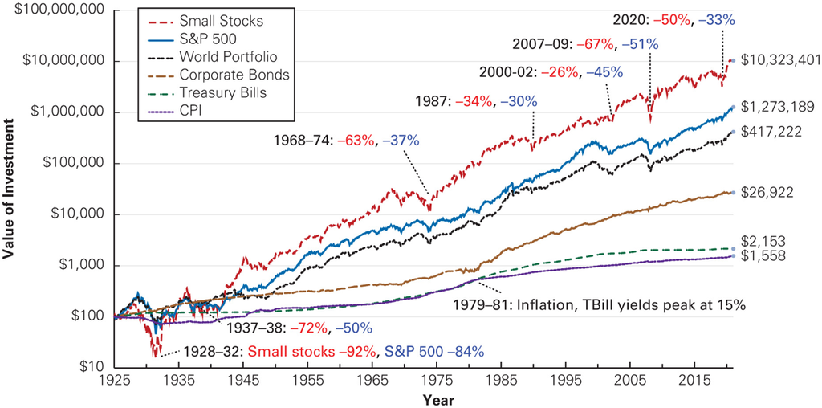

Source: CRSP, Standard and Poor’s, MSCI, Global Financial Data.

## Value of $100 invested in different years and for differing horizons

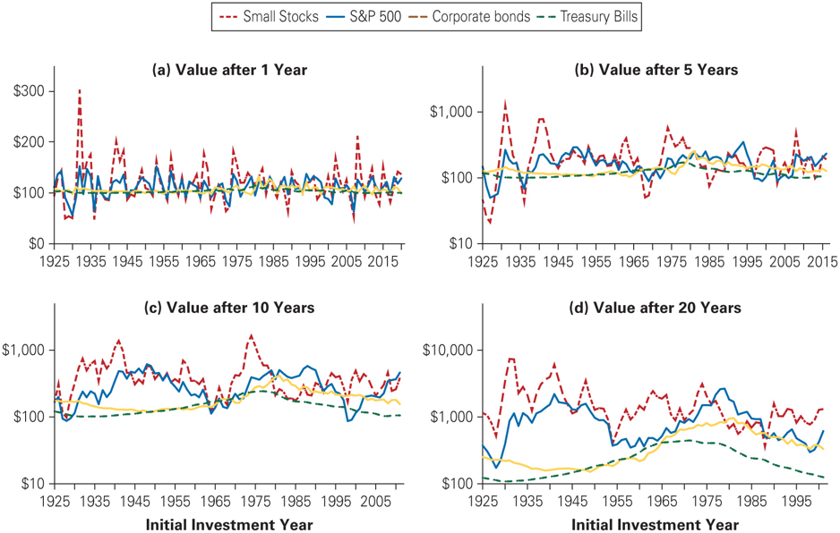

Source: CRSP, Standard and Poor’s, MSCI, Global Financial Data.

## B. Common return measures

How to determine the return of a financial asset?

- Returns from dividends and capital gains
- Calculations with reinvested dividends
- Stock market indices
- Histograms of historical returns
- Historical volatility
- Arithmetic mean versus geometric mean

## Dividend return and capital gains

- The realized return of a stock between two dates consists of:
  - capital gains and
  - dividends

  $$\begin{aligned}
  R_{t+1} & = \frac{\text{Wealth at period end}}{\text{Initial investment}} - 1 \\
  & = \frac{P_{t+1} + Div_{t+1} - P_{t}}{P_{t}} \\
  & = \underbrace{\frac{P_{t+1} - P_{t}}{P_{t}}}_{\text{Capital Gain Rate}} + \underbrace{\frac{Div_{t+1}}{P_{t}}}_{\text{Dividend Yield}}
  \end{aligned}$$

## Stock prices and dividend payment: the example of BNP Paribas

A dividend of EUR 2.7 is detached from the share price on May 30th, 2017

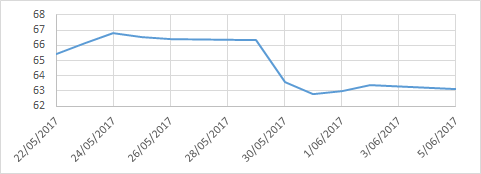

Source: Yahoo Finance

## How to calculate the average return on an investment?

- What is the better investment (Investment at the end of year N until year N+2)?

  | Investment 1 |  |  |  |  |
  | --- | --- | --- | --- | --- |
  | Value | 100 | 50 | 100 | Average |
  | Return |  | -50% | +100% | +25 % |
  | Investment 2 |  |  |  |  |
  | Value | 100 | 110 | 121 |  |
  | Return |  | +10% | +10% | +10% |

  . . .
- The arithmetic average is misleading …

## Geometric mean (annualized), or CAGR

- CAGR stands for **Compound Annual Growth Rate**: the constant yearly return that turns the initial investment into the final wealth.
- The geometric mean is calculated as

  $$\text{Geometric mean} = \left(\frac{\text{Wealth at the end of n years}}{\text{Initial investment}}\right)^{\frac{1}{n}} - 1$$
- or

  $$\text{Geometric mean} = \left(\left(1+R_{1}\right) \left(1+R_{2}\right)\dots \left(1+R_{n}\right)\right)^{\frac{1}{n}} - 1$$

## To sum up: calculation of returns

- Depending on the situation, it is best to calculate mean returns differently. In general:
  - Intertemporal average or realized returns: geometric mean (=IRR of the investment, or “compound annual return”)
  - Mean return of multiple investments or expected return: arithmetic mean
- The two means are equal if annual returns are constant. Otherwise the arithmetic mean is always larger than the geometric mean.
- The geometric mean is approximately equal to the arithmetic mean - $\frac{1}{2}$ variance.

## Compounding returns

- The returns over multiple periods need to be compounded to obtain the return over a longer horizon.
- Example: Over 4 consecutive periods an investment generates the returns: 6.1%, -5.32%, 6.72% and 8.93%. The overall return is:
  $$\begin{aligned}
  R_{1 \to 4} & = \left(1+R_{1}\right) \left(1+R_{2}\right) \left(1+R_{3}\right) \left(1+R_{4}\right) - 1 \\
  & = \left(1+0.061\right) \left(1-0.0532\right) \left(1+0.0672\right) \left(1+0.0893\right) - 1 \\
  & = 16.7\%
  \end{aligned}$$
- Remarks:
  - You must not take the sum of the returns!
  - The length of the periods does not matter here.

## Example: accounting for reinvested dividends to compute the returns on Total

What was the total return of the Total stock in 2016 (rounded to 4 decimal points)?

| Date | Price | Dividend | Return |
| --- | --- | --- | --- |
|  | (in EUR) | (in EUR) |  |
| 01/01/2016 | 40.89 |  |  |
| 21/03/2016 | 41.33 | 0.61 | 2.57% |
| 06/06/2016 | 42.47 | 0.61 | 4.23% |
| 27/09/2016 | 40.77 | 0.61 | -2.57% |
| 21/12/2016 | 47.60 | 0.61 | 18.25% |
| 31/12/2016 | 48.72 |  | 2.35% |

## Returns and “stock splits”

- Companies sometimes decide to do “stock splits”, or “reverse stock splits”, which need to be taken into account when returns are calculated.
- Example:
- You bought 100 stocks of CIGNA Corp. on August 5th, 2006 for a price of $155.59. One year later, the stock is worth $50.18, but the company has done a “3:1 stock split” so you now own 300 stocks. Over this period, you received a total amount of dividends of $8.5 (on all your stocks). Your total return is
  $$\frac{300 \times 50.18+8.5-100 \times 155.59}{100 \times 155.59} = -3.2\%.$$

## Value of a stock and performance index

- The previous figures don’t correspond to the evolution of a specific stock price.
  - They represent the evolution of an investment in the stock.
- They are a “performance index” and/or use “adjusted prices”.
- The adjusted stock price accounts for dividends and stock splits. They are calculated such that
  - The last value corresponds to the stock price.
  - The previous values mirror the evolution of an investment in the stock.

## Example: the long-term return on a stock

- On January 2nd, 1970, the Coca Cola stock price was worth $82.25. On June 30th, 2017, the stock price was worth $44.85. Good or bad investment?
- Coca Cola has done 5 stock splits and made many dividend payments, the “adjusted close” on 2.1.1970 was 0.85.
- Hence, the return on the overall period 1970-2017 is $44.85/0.85-1=5176\%$.
- The geometric annual mean is $(44.85/0.85)^{1/47}-1=8.80\%$.

## Stock price indices

- The stock price indices aggregate the information about the evolution of a stock exchange by depicting the evolution of a portfolio of stocks.
- Example: CAC 40, DAX, S&P 500, FTSE100 (Footsie), Nasdaq 100, Dow Jones Industrial average, Hang Seng, Nikkei 225 etc.
- Some of these indices are very old!
  - Dow Jones has published its index since 1896 in New-York
- **Attention**: These indices can be calculated as “total return index” including dividends or “price index” without dividends! Some indices exist in different versions.

## Which indices include dividends?

| Gross total return: dividends reinvested | Price only |
| --- | --- |
| DAX 40 (Germany) | S&P 500, Dow Jones, Nasdaq (US) |
| Ibovespa (Brazil) | FTSE 100 (UK) |
|  | Nikkei 225 (Japan) |
|  | CAC 40 (France) |
|  | Hang Seng (Hong Kong) |

- **Price index**: when a company pays a dividend, its share price drops, and the index does not add that cash back. It only measures price changes.
- **Total return index**: assumes every dividend is reinvested in the index, before tax, so it grows faster over time.
- Most price indices also have an official total return version, e.g. the S&P 500 TR or the CAC 40 GR.

## The same index comes in three versions

- **Price index** (price-only or capital index): follows share prices only. When a company pays a dividend its price drops and the index drops with it; the cash is never added back. The headline S&P 500, Dow Jones, FTSE 100, CAC 40 and Nikkei 225 are all price indices.
- **Gross total return index** (gross return or performance index): every dividend is reinvested in the index on the day it is paid, before any tax. Examples: the DAX 40 as quoted in the news, the S&P 500 TR, the CAC 40 GR.
- **Net total return index** (net return index): dividends are reinvested after the withholding tax a foreign investor would pay. The usual benchmark for international funds and ETFs. Examples: MSCI World Net, S&P 500 Net.
- Same companies, same prices in all three. The only difference is what happens to the dividends, and over the long run that difference is large.

## CAC40 and CAC40 GR (gross return)

[figure not shown]

## C. Historical returns of stocks and bonds

Annual mean return
$$\overline{R} = \frac{1}{T} \sum^{T}_{t=1} R_{t} = \frac{1}{T}\left(R_{1} + \dots + R_{T} \right)$$

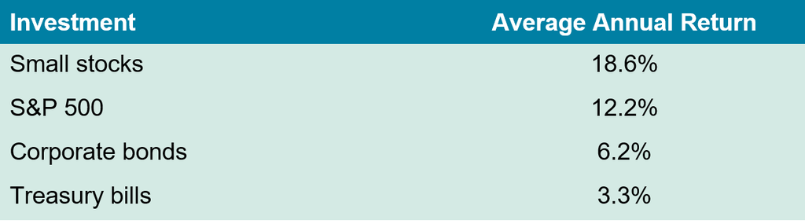

## Return histograms of different US portfolios (1926-2021)

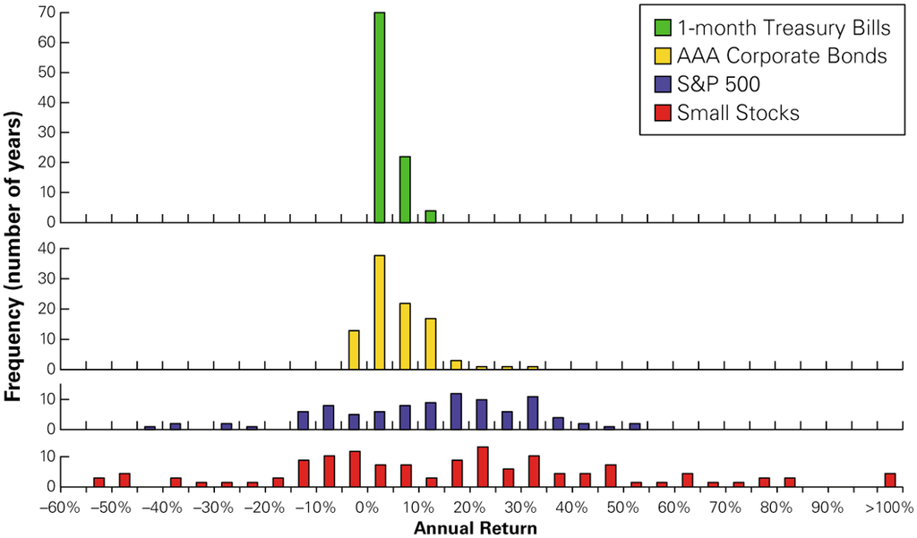

## D. Common measures of risk

- There is no perfect and generally accepted risk measure.
- In finance, risk is measured by volatility.
- Volatility = standard deviation of the returns

  First calculate the variance, then take its square root to get the volatility:

  $$\text{Var}\left[ R \right] = \frac{1}{T-1} \sum^{T}_{t=1} \left(R_{t} - \overline{R}\right)^{2} \qquad\qquad \sigma_{R} = \sqrt{\text{Var}\left[ R \right]}$$
- Attention:
  - The volatility is a symmetric risk measure. It takes into account the risk to win as well as the risk to lose!
  - Other measures capture only the risk of losses (downside risk), e.g. VaR (“value at risk”).

## E. The historical risk and return trade-off

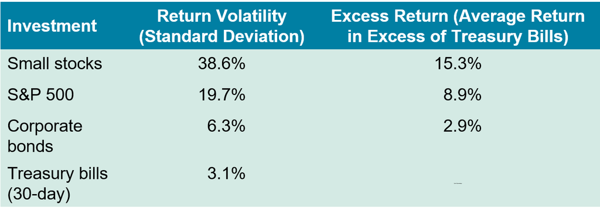

$$\begin{aligned}
\operatorname{Excess \ return} & = \operatorname{return \ in \ excess \ of \ the \ risk-free \ rate} \\
& = \operatorname{risk \ premium}
\end{aligned}$$

## Return/risk of different US portfolios

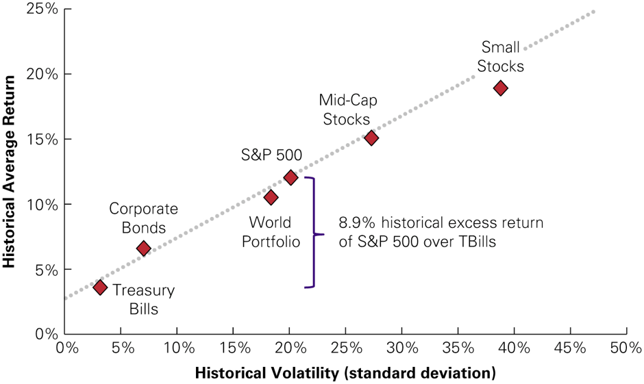

Source: CRSP, Morgan Stanley Capital International

## F. Risk and returns of individual stocks

Volatility and realized returns on S&P 500 stocks

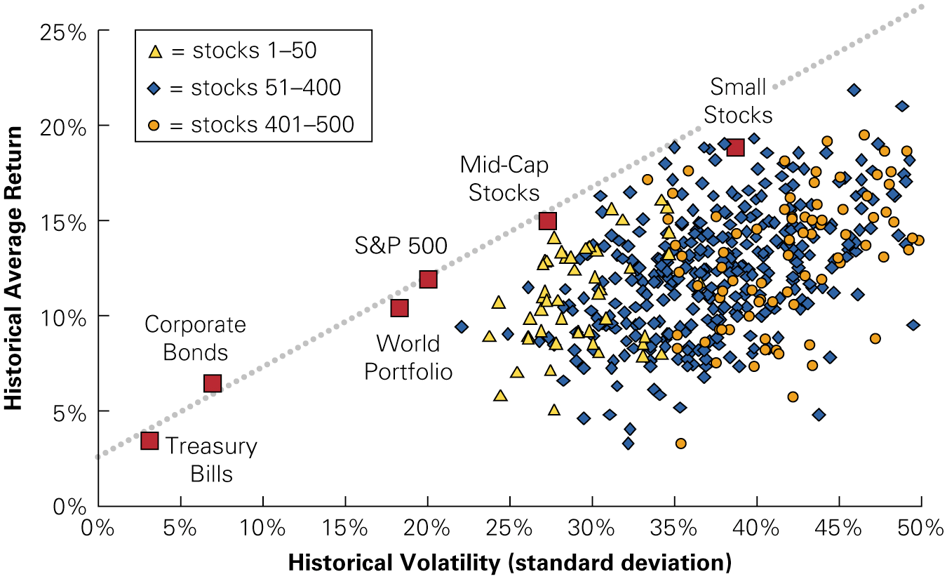

Source: CRSP, Morgan Stanley Capital International

## What’s “new”? The low-risk anomaly

All stocks:

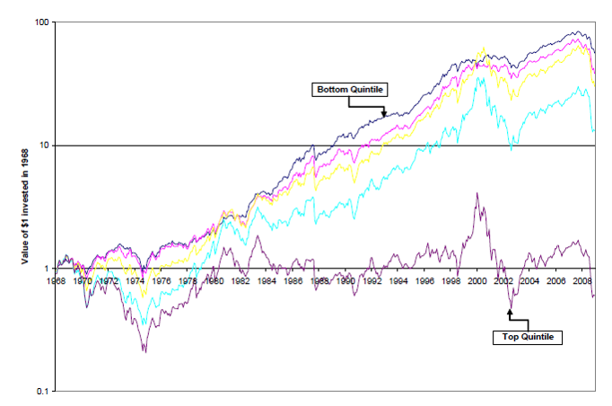

Baker, Bradley and Wurgler (2011).

## What’s “new”? The low-risk anomaly (con’t)

Top 1000 stocks by MktCap

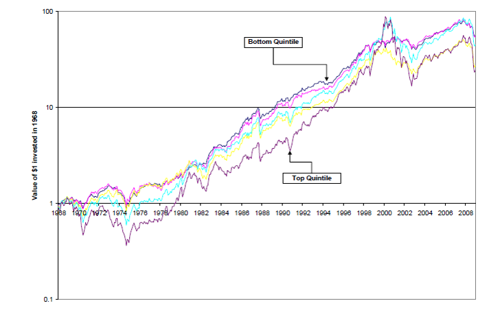

Baker, Bradley and Wurgler (2011).

## Quiz

- A stock is worth $1 at the beginning of the year. At the end of the year and after a reverse stock split of 1:10 and a dividend of $0.03 (before the split), the stock is worth $11. What is the return on the investment?
- The value of a stock is halved over six month (without stock split and dividends).
  - What is the return on the investment over the six months?
  - What is the annualized return?
- The value of a stock loses 20% and then gains 20% (without stock split and dividends).
  - What is the average arithmetic return?
  - What is the average geometric return?

## Quiz

- Your banker explains to you that stocks always offer a better return than your investment in treasury bills.
  - Is this true?
  - Is it a reason to invest in stocks?
- Can volatility become negative?
- Is the return on a stock with more risk always higher than the return on a stock with less risk?

## Critical thinking

- A bond is worth $97 (for a nominal value of $100) at the beginning of the year. The bond pays an annual coupon of 4.5%, and is worth $102 at the end of the year. What is the return on the investment?
- A company’s stock price increases by 10% over the year, but the return on equity (ROE) of the company is -30%. Is there a contradiction?